# Simulation: parameter recovery as a function of available data

Thomas Wilschut Last updated: 2026-10-01

This markdown file is can be used to reproduce the results reported in the paper: Idiographic Memory Modelling in ACT-R using Alternating Maximum Likelihood Estimation

This script is used for the recovery analysis, reported in the section: Simulation: Recovering parameters from synthetic data.

# Setup

```r
library(data.table)
library(here)
library(ggplot2)
library(furrr)
library(patchwork)
library(ggsci)
library(Rcpp)
library(GGally)
library(tidyverse)

# Parallel backend
plan(multisession, workers = availableCores() - 1)

# Source simulation + fitting functions (which also compile actr_ll.cpp)
source(here::here("R", "sim-mle.R"))

# Plot aesthetics
col_blue <- "#0571b0"
col_red  <- "#ca0020"
plottheme <- theme_bw(base_size = 12)
```

# Simulate a larger dataset for recovery

For the recovery analysis we generate a single large dataset (50 repetitions per fact) once, and then subset it down to smaller numbers of repetitions and facts in the grid below. Generating the maximum amount of data up front and subsetting it keeps the underlying learners and facts identical across all data-quantity conditions, so differences in recovery reflect the amount of data rather than a different random draw.

```r
sim <- simulate_fact_learner_data(
  n_learners    = 50,
  n_facts       = 15,
  n_repetitions = 50,   # generate plenty; we'll subset later
  seed          = 999
)
```

[output not shown]

```r
sim_test <- sim[is_study == FALSE]
```

# Run recovery across grid

We vary the amount of available data along two axes: the number of repetitions per fact (holding facts fixed at 15) and the number of facts per learner (holding repetitions fixed at 10). For each grid point we refit all 50 learners and record the recovered parameters. As with the greedy step, this is expensive, so the chunk is `eval = FALSE` and the results are cached to `data/processed/fits/`; the next chunk reloads them.

```r
rep_levels  <- c(1, 2, 4, 6, 8, 10, 15, 20, 30)
fact_levels <- c(1, 2, 4, 6, 8, 10, 15, 20, 30)

fits_vary_reps <-
  map_dfr(rep_levels, function(nr) {
    cat(sprintf("\n=== Fitting n_reps = %d ===\n", nr))
    res <- run_recovery_grid(sim, n_reps = nr, n_facts = 15)
    res$n_repetitions <- nr
    res$n_facts_grid  <- 15
    res
  })

fits_vary_facts <-
  map_dfr(fact_levels, function(nf) {
    cat(sprintf("\n=== Fitting n_facts = %d ===\n", nf))
    res <- run_recovery_grid(sim, n_reps = 10, n_facts = nf)
    res$n_repetitions <- 10
    res$n_facts_grid  <- nf
    res
  })

saveRDS(fits_vary_reps,  here::here("data", "processed", "fits", "results_recovery_vary_reps.rds"))
saveRDS(fits_vary_facts, here::here("data", "processed", "fits", "results_recovery_vary_facts.rds"))
```

# Load results (if saved earlier)

```r
fits_vary_reps  <- readRDS(here::here("data", "processed", "fits", "results_recovery_vary_reps.rds"))
fits_vary_facts <- readRDS(here::here("data", "processed", "fits", "results_recovery_vary_facts.rds"))

# Backward compatibility: rename old column names from pre-phi cached fits
if ("alpha"           %in% names(fits_vary_reps))  setnames(fits_vary_reps,  "alpha",           "phi")
if ("delta_alpha_est" %in% names(fits_vary_reps))  setnames(fits_vary_reps,  "delta_alpha_est", "delta_phi_est")
if ("alpha"           %in% names(fits_vary_facts)) setnames(fits_vary_facts, "alpha",           "phi")
if ("delta_alpha_est" %in% names(fits_vary_facts)) setnames(fits_vary_facts, "delta_alpha_est", "delta_phi_est")

names(fits_vary_reps)
```

```
##  [1] "n_repetitions" "n_facts_grid"  "user_id"       "iteration"
##  [5] "phi"           "tau"           "s"             "lf"
##  [9] "ter"           "ll"            "n_iter"        "delta_phi_est"
```

# Merge true parameters

To assess recovery we need the ground-truth parameter values alongside the recovered estimates. Here we extract the true person-level parameters (one row per learner) and join them onto the recovered fits from both grids.

```r
true_params <- sim_test[, .(
  true_phi = true_phi[1],
  true_tau = true_tau[1],
  true_s   = true_s[1],
  true_F   = true_lf[1],
  true_ter = true_ter[1]
), by = user_id]

recovery_reps  <- merge(fits_vary_reps,  true_params, by = "user_id")
recovery_facts <- merge(fits_vary_facts, true_params, by = "user_id")
```

# Recovery (Figure 5)

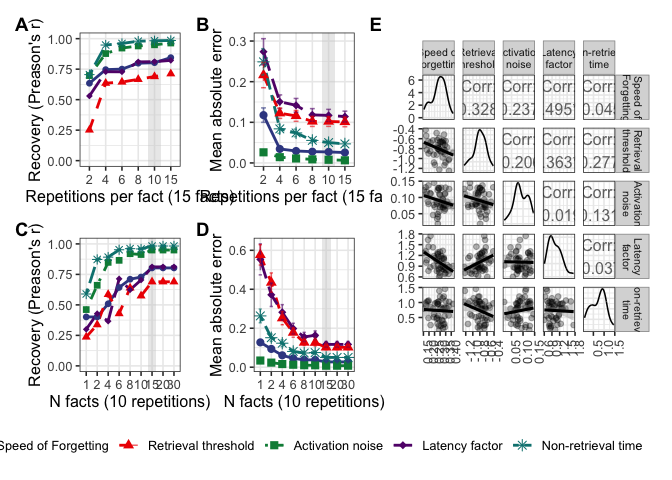

```r
# ── Shared aesthetics (consistent with other plots) ───────────────────────────
param_levels <- c(
  "Speed of Forgetting", "Retrieval threshold", "Activation noise",
  "Latency factor", "Non-retrieval time"
)

param_colors    <- setNames(pal_aaas()(5), param_levels)
param_shapes    <- setNames(c(16, 17, 15, 18, 8),                              param_levels)
param_linetypes <- setNames(c("solid", "dashed", "dotdash", "longdash", "twodash"), param_levels)

# ── Panel A: Scatter plots ────────────────────────────────────────────────────
subset_10 <- recovery_reps[n_repetitions == 10]

plot_df <- subset_10 %>%
  pivot_longer(cols = c(phi, tau, s, lf, ter),
               names_to = "param", values_to = "estimate") %>%
  mutate(
    true_value = case_when(
      param == "phi" ~ true_phi,
      param == "tau" ~ true_tau,
      param == "s"   ~ true_s,
      param == "lf"  ~ true_F,
      param == "ter" ~ true_ter
    ),
    param_label = recode(param,
      "phi" = "Speed of Forgetting",
      "tau" = "Retrieval threshold",
      "s"   = "Activation noise",
      "lf"  = "Latency factor",
      "ter" = "Non-retrieval time"
    ),
    param_label = factor(param_label, levels = param_levels)
  )

learner_corrs <- plot_df %>%
  group_by(param_label) %>%
  summarise(r = cor(estimate, true_value, use = "complete.obs"), .groups = "drop") %>%
  mutate(r_lab = paste0("r = ", format(round(r, 2), nsmall = 2)))

p_recovery <- ggplot(plot_df, aes(x = true_value, y = estimate, color = param_label)) +
  geom_point(alpha = 0.85, size = 2) +
  geom_smooth(method = "lm", se = TRUE, colour = "black") +
  geom_text(data = learner_corrs,
            aes(x = -Inf, y = Inf, label = r_lab),
            inherit.aes = FALSE, hjust = -0.1, vjust = 2, size = 4) +
  facet_wrap(~ param_label, scales = "free", ncol = 5) +
  coord_cartesian(clip = "off") +
  scale_color_manual(values = param_colors) +
  plottheme +
  theme(
    legend.position  = "none",
    strip.background = element_rect(fill = "grey85", colour = "grey60"),
    strip.text       = element_text(size = 9)
  ) +
  labs(x = "Original value", y = "Recovered value")

# ── Helper functions ──────────────────────────────────────────────────────────
make_cor_summary <- function(df, group_var) {
  df %>%
    group_by(!!sym(group_var)) %>%
    summarise(
      cor_phi = cor(true_phi, phi, use = "complete.obs"),
      cor_tau = cor(true_tau, tau, use = "complete.obs"),
      cor_s   = cor(true_s,   s,   use = "complete.obs"),
      cor_F   = cor(true_F,   lf,  use = "complete.obs"),
      cor_ter = cor(true_ter, ter, use = "complete.obs"),
      .groups = "drop"
    ) %>%
    pivot_longer(starts_with("cor_"), names_to = "parameter", values_to = "correlation") %>%
    mutate(
      parameter   = sub("cor_", "", parameter),
      param_label = recode(parameter,
        "phi" = "Speed of Forgetting",
        "tau" = "Retrieval threshold",
        "s"   = "Activation noise",
        "F"   = "Latency factor",
        "ter" = "Non-retrieval time"
      ),
      param_label = factor(param_label, levels = param_levels)
    )
}

make_error_summary <- function(df, group_var) {
  df %>%
    mutate(
      phi_error = abs(true_phi - phi),
      tau_error = abs(true_tau - tau),
      s_error   = abs(true_s   - s),
      F_error   = abs(true_F   - lf),
      ter_error = abs(true_ter - ter)
    ) %>%
    pivot_longer(ends_with("_error"), names_to = "parameter", values_to = "abs_error") %>%
    group_by(parameter, !!sym(group_var)) %>%
    summarise(mean_error = mean(abs_error, na.rm = TRUE),
              se_error   = sd(abs_error,   na.rm = TRUE) / sqrt(n()),
              .groups = "drop") %>%
    mutate(
      param_label = recode(parameter,
        "phi_error" = "Speed of Forgetting",
        "tau_error" = "Retrieval threshold",
        "s_error"   = "Activation noise",
        "F_error"   = "Latency factor",
        "ter_error" = "Non-retrieval time"
      ),
      param_label = factor(param_label, levels = param_levels)
    )
}

# ── Shared scale layers ───────────────────────────────────────────────────────
scales_shared <- list(
  scale_color_manual(values = param_colors),
  scale_linetype_manual(values = param_linetypes),
  scale_shape_manual(values = param_shapes),
  guides(colour = guide_legend(override.aes = list(
    linetype = param_linetypes, shape = param_shapes)),
    linetype = "none", shape = "none")
)

plot_cor <- function(df, x_var, x_lab, highlight_x = NULL) {
  p <- ggplot(df, aes(x = factor(!!sym(x_var)), y = correlation,
                      colour = param_label, linetype = param_label,
                      shape = param_label, group = param_label))
  if (!is.null(highlight_x)) {
    p <- p + annotate("rect",
      xmin = which(levels(factor(df[[x_var]])) == as.character(highlight_x)) - 0.4,
      xmax = which(levels(factor(df[[x_var]])) == as.character(highlight_x)) + 0.4,
      ymin = -Inf, ymax = Inf, fill = "grey80", alpha = 0.4)
  }
  p + geom_line(linewidth = 1) + geom_point(size = 2) +
    scale_y_continuous(limits = c(0, 1)) +
    scales_shared +
    plottheme +
    theme(legend.position = "none") +
    labs(x = x_lab, y = "Recovery (Preason's r)")
}

plot_error <- function(df, x_var, x_lab, highlight_x = NULL) {
  p <- ggplot(df, aes(x = factor(!!sym(x_var)), y = mean_error,
                      colour = param_label, linetype = param_label,
                      shape = param_label, group = param_label))
  if (!is.null(highlight_x)) {
    p <- p + annotate("rect",
      xmin = which(levels(factor(df[[x_var]])) == as.character(highlight_x)) - 0.4,
      xmax = which(levels(factor(df[[x_var]])) == as.character(highlight_x)) + 0.4,
      ymin = -Inf, ymax = Inf, fill = "grey80", alpha = 0.4)
  }
  p + geom_line(linewidth = 1) + geom_point(size = 2.5) +
    geom_errorbar(aes(ymin = mean_error - se_error, ymax = mean_error + se_error),
                  width = 0.3, alpha = 0.6) +
    scales_shared +
    plottheme +
    theme(legend.position = "none") +
    labs(x = x_lab, y = "Mean absolute error")
}

# ── Panels B–E ────────────────────────────────────────────────────────────────
cor_reps   <- make_cor_summary(recovery_reps, "n_repetitions")
error_reps <- make_error_summary(recovery_reps, "n_repetitions")
cor_facts  <- make_cor_summary(recovery_facts, "n_facts_grid")
error_facts <- make_error_summary(recovery_facts, "n_facts_grid")

p_corr_reps  <- plot_cor(cor_reps  %>% filter(n_repetitions < 20), "n_repetitions", "Repetitions per fact (15 facts)", highlight_x = 10)
p_error_reps <- plot_error(error_reps %>% filter(n_repetitions < 20), "n_repetitions", "Repetitions per fact (15 facts)", highlight_x = 10)
p_corr_facts  <- plot_cor(cor_facts,  "n_facts_grid", "N facts (10 repetitions)", highlight_x = 15)
p_error_facts <- plot_error(error_facts, "n_facts_grid", "N facts (10 repetitions)", highlight_x = 15)

# ── Panel F: Pairwise correlations ────────────────────────────────────────────
pairs_df <- subset_10[, .(phi, tau, s, lf, ter)]


pairs_plot <- ggpairs(
  as.data.frame(pairs_df),
  upper = list(continuous = function(data, mapping, ...) {
    ggally_cor(data, mapping, ...)
  }),
  lower = list(continuous = function(data, mapping, ...) {
    ggplot(data, mapping) +
      geom_point(alpha = 0.3) +
      geom_smooth(method = "lm", se = TRUE, color = "black")
  }),
  columnLabels = c("Speed of\nForgetting", "Retrieval\nthreshold",
                 "Activation\nnoise", "Latency\nfactor", "Non-retrieval\ntime")
) +
  plottheme +
  theme(strip.background = element_rect(fill = "grey85", colour = "grey60"),
        strip.text       = element_text(size = 8),
        axis.text.x      = element_text(angle = 90, hjust = 1))


# ── Combined figure ───────────────────────────────────────────────────────────
pairs_grob <- GGally::ggmatrix_gtable(pairs_plot)
p_corr_reps <- p_corr_reps + theme(legend.position = "none")
p_error_reps <- p_error_reps + theme(legend.position = "none")
p_corr_facts <- p_corr_facts + theme(legend.position = "none")
p_error_facts <- p_error_facts + theme(legend.position = "bottom", # remeove legend title:
                                       legend.title = element_blank()
                                       )

combined <-
  ((p_corr_reps + p_error_reps) / (p_corr_facts + p_error_facts) |
     wrap_elements(pairs_grob)) +
  plot_layout(widths = c(1, 1)) +
  plot_annotation(tag_levels = "A") &
  theme(plot.tag = element_text(face = "bold", size = 14))

combined
```

```r
# Paper Figure 5: recovery of participant-level parameters as a function of available data
ggsave(here::here("output", "recovery_combined.png"), combined, width = 11, height = 6.5)
```

# Fact-level Δφ recovery (Figure 6)

Besides the person-level parameters, the model estimates a Speed of Forgetting offset (Δφ) for each individual fact. Here we assess how well those fact-level offsets are recovered (Figure 6 in the paper): panel A is a true-vs-recovered scatter at 10 repetitions, and panels B and C show recovery (correlation) and mean absolute error as a function of the number of repetitions per fact. The recovered offsets are stored as a named list-column in the fits, so `get_delta_phi()` unpacks them into a long table keyed by fact before merging on the true values.

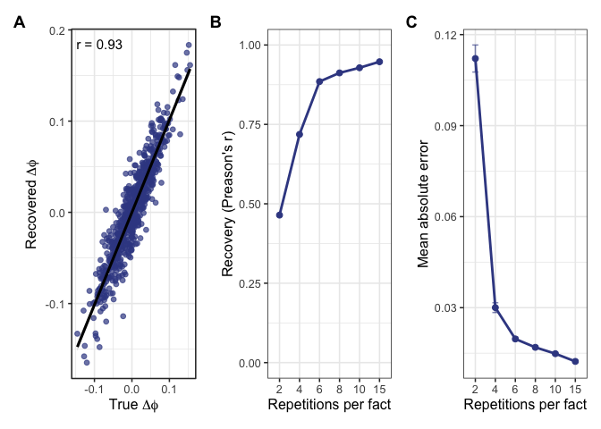

```r
# Extract true fact offsets
true_offsets <- sim_test[, .(true_delta_phi = true_fact_offset[1]),
                         by = .(user_id, fact_id)]

# Extract recovered offsets from fits
get_delta_phi <- function(fits_df) {
  fits_df[, {
    da <- delta_phi_est[[1]]
    if (is.null(da) || length(da) == 0) {
      NULL
    } else {
      fact_ids <- as.integer(sub("^d_", "", names(da)))
      .(fact_id = fact_ids,
        delta_phi_est = as.numeric(da))
    }
  }, by = .(user_id, n_repetitions)]
}

fact_recovery <- get_delta_phi(fits_vary_reps) %>% filter(n_repetitions < 20)
fact_recovery <- merge(fact_recovery, true_offsets, by = c("user_id", "fact_id"))

# (A) Scatter at 10 reps
fact_10 <- fact_recovery[n_repetitions == 10]
r_val <- cor(fact_10$true_delta_phi, fact_10$delta_phi_est, use = "complete.obs")

p_fact_scatter <- ggplot(fact_10, aes(x = true_delta_phi, y = delta_phi_est)) +
  geom_point(alpha = 0.7, color = pal_aaas()(1)) +
  geom_smooth(method = "lm", color = "black", se = TRUE) +
  annotate("text", x = -Inf, y = Inf,
           label = sprintf("r = %.2f", r_val),
           hjust = -0.1, vjust = 2, size = 4) +
  coord_cartesian(clip = "off") +
  labs(x = expression("True "*Delta*phi),
       y = expression("Recovered "*Delta*phi)) +
  plottheme

# (B) Correlation over reps
fact_corr <- fact_recovery[, .(corr = cor(true_delta_phi, delta_phi_est, use = "complete.obs")),
                           by = n_repetitions]

p_fact_corr <- ggplot(fact_corr, aes(x = factor(n_repetitions), y = corr, group = 1)) +
  geom_line(linewidth = 1, color = pal_aaas()(1)) +
  geom_point(size = 2, color = pal_aaas()(1)) +
  scale_y_continuous(limits = c(0, 1)) +
  labs(x = "Repetitions per fact", y = "Recovery (Preason's r)") +
  plottheme

# (C) Error over reps
fact_error <- fact_recovery[, .(
  mean_error = mean(abs(true_delta_phi - delta_phi_est), na.rm = TRUE),
  se_error = sd(abs(true_delta_phi - delta_phi_est), na.rm = TRUE) / sqrt(.N)
), by = n_repetitions]

p_fact_error <- ggplot(fact_error, aes(x = factor(n_repetitions), y = mean_error, group = 1)) +
  geom_line(linewidth = 1, color = pal_aaas()(1)) +
  geom_point(size = 2, color = pal_aaas()(1)) +
  geom_errorbar(aes(ymin = mean_error - se_error, ymax = mean_error + se_error),
                width = 0.3, alpha = 0.6, color = pal_aaas()(1)) +
  labs(x = "Repetitions per fact", y = "Mean absolute error") +
  plottheme

(p_fact_scatter + p_fact_corr + p_fact_error) +
  plot_annotation(tag_levels = "A") &
  theme(
    plot.tag = element_text(face = "bold", size = 14)
  )
```

```r
# Paper Figure 6: recovery of fact-level Speed of Forgetting offsets (delta-phi)
ggsave(here::here("output", "fact_level_recovery.png"), width = 10, height = 3.5)
```

# Correlations of the true parameters

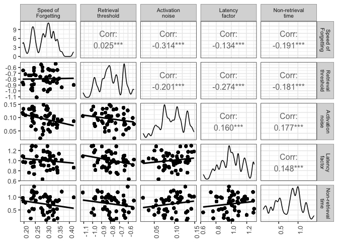

```r
true_param_pairs <- sim_test[, .(true_phi, true_tau, true_s, true_lf, true_ter)]
pairs_true <- ggpairs(
  as.data.frame(true_param_pairs),
  upper = list(continuous = function(data, mapping, ...) {
    ggally_cor(data, mapping, ...)
  }),
  lower = list(continuous = function(data, mapping, ...) {
    ggplot(data, mapping) +
      geom_point(alpha = 0.3) +
      geom_smooth(method = "lm", se = TRUE, color = "black")
  }),
  columnLabels = c("Speed of\nForgetting", "Retrieval\nthreshold",
                 "Activation\nnoise", "Latency\nfactor", "Non-retrieval\ntime")
) +
  plottheme +
  theme(strip.background = element_rect(fill = "grey85", colour = "grey60"),
        strip.text       = element_text(size = 8),
        axis.text.x      = element_text(angle = 90, hjust = 1))
pairs_true
```

# Stepwise decomposition of recovery figures (for slides)

Export panels A (recovery vs. repetitions) and C (recovery vs. facts) in five cumulative steps, adding one parameter at a time in the canonical order used throughout the paper: φ → τ → s → F → t_er. Each step is saved as both PNG and SVG.

```r
dir.create(here::here("output", "recovery_stepwise"), showWarnings = FALSE)

# Canonical parameter sequence (matches param_levels order throughout paper)
param_seq <- c(
  "Speed of Forgetting",
  "Retrieval threshold",
  "Activation noise",
  "Latency factor",
  "Non-retrieval time"
)

# File-name slugs matching the sequence
param_slugs <- c("phi", "tau", "s", "lf", "ter")

# ── Stepwise plot helper ────────────────────────────────────────────────────
# Same aesthetics as plot_cor but only draws the params in `show_params`
plot_cor_step <- function(df, x_var, x_lab, show_params, highlight_x = NULL) {
  df_sub <- df[df$param_label %in% show_params, ]
  # Keep factor levels in canonical order so colours stay consistent
  df_sub$param_label <- factor(df_sub$param_label, levels = param_levels)

  p <- ggplot(df_sub,
              aes(x = factor(!!sym(x_var)), y = correlation,
                  colour = param_label, linetype = param_label,
                  shape = param_label, group = param_label))

  if (!is.null(highlight_x)) {
    p <- p + annotate("rect",
      xmin = which(levels(factor(df_sub[[x_var]])) == as.character(highlight_x)) - 0.4,
      xmax = which(levels(factor(df_sub[[x_var]])) == as.character(highlight_x)) + 0.4,
      ymin = -Inf, ymax = Inf, fill = "grey80", alpha = 0.4)
  }

  p +
    geom_line(linewidth = 1) +
    geom_point(size = 2) +
    scale_y_continuous(limits = c(0, 1)) +
    # Use the same shared scales so colours are always identical across steps
    scale_color_manual(values = param_colors, breaks = param_levels,
                       drop = FALSE) +
    scale_linetype_manual(values = param_linetypes, breaks = param_levels,
                          drop = FALSE) +
    scale_shape_manual(values = param_shapes, breaks = param_levels,
                       drop = FALSE) +
    guides(colour   = guide_legend(override.aes = list(
                        linetype = param_linetypes[param_levels],
                        shape    = param_shapes[param_levels]),
                        ncol = 1),
           linetype = "none", shape = "none") +
    plottheme +
    theme(legend.position  = "right",
          legend.title     = element_blank(),
          legend.text      = element_text(size = 9),
          legend.key.width = unit(1.5, "cm")) +
    labs(x = x_lab, y = "Recovery (Pearson's r)")
}

# ── Export loop ─────────────────────────────────────────────────────────────
# cor_reps / cor_facts were computed in the Recovery chunk above
# (filtered to n_repetitions < 20 for panel A, full range for panel C)
cor_reps_slide  <- cor_reps  %>% filter(n_repetitions < 20)
cor_facts_slide <- cor_facts

for (i in seq_along(param_seq)) {
  shown  <- param_seq[seq_len(i)]
  slug   <- paste(param_slugs[seq_len(i)], collapse = "-")
  prefix <- sprintf("step_%02d_%s", i, slug)

  p_step_reps  <- plot_cor_step(
    cor_reps_slide, "n_repetitions",
    "Repetitions per fact (15 facts)",
    show_params = shown, highlight_x = 10
  )

  p_step_facts <- plot_cor_step(
    cor_facts_slide, "n_facts_grid",
    "N facts (10 repetitions)",
    show_params = shown, highlight_x = 15
  )

  # Panel A: recovery vs repetitions
  ggsave(here::here("output", "recovery_stepwise",
                    paste0(prefix, "_reps.png")),
         p_step_reps, width = 5.5, height = 5, dpi = 150)
  ggsave(here::here("output", "recovery_stepwise",
                    paste0(prefix, "_reps.svg")),
         p_step_reps, width = 5.5, height = 5)

  # Panel C: recovery vs facts
  ggsave(here::here("output", "recovery_stepwise",
                    paste0(prefix, "_facts.png")),
         p_step_facts, width = 5.5, height = 5, dpi = 150)
  ggsave(here::here("output", "recovery_stepwise",
                    paste0(prefix, "_facts.svg")),
         p_step_facts, width = 5.5, height = 5)

  cat(sprintf("Exported step %d/%d: %s\n", i, length(param_seq), prefix))
}
```

```
## Exported step 1/5: step_01_phi

## Exported step 2/5: step_02_phi-tau

## Exported step 3/5: step_03_phi-tau-s

## Exported step 4/5: step_04_phi-tau-s-lf

## Exported step 5/5: step_05_phi-tau-s-lf-ter
```